# pml-assign

Abdul Q Khan

June 11, 2017

## Clean and Import Data

Load the data by downloading the files and saving adding them. Training set is 19622X60 and test is 20X60 The scrubbed data is 19622 with 53 variable and 20 with 53 variables. “classes as last”

```r
library(rattle);
library(RColorBrewer);
library(rmarkdown);
library(knitr);
library(caret)
library(randomForest)
```

```r
library(rpart)
library(rpart.plot)
library(repmis);
#import data and load data from local file
training <- read.csv("C:\\projects\\practicleML\\pml-training.csv", na.strings = c("NA", ""))
testing <- read.csv("C:\\projects\\practicleML\\pml-testing.csv", na.strings = c("NA", ""))
#remove /null/empty values
training <- training[, colSums(is.na(training)) == 0]
testing <- testing[, colSums(is.na(testing)) == 0]
```

Partition Data In order to get out-of-sample errors, we split the cleaned training set training_data into a training set (train, 70%) for prediction and a validation set (valid 30%) to compute the out-of-sample errors. # Also remove first seven columns/predictors as the does not impact predictions

```r
training_data <- training[, -c(1:7)]
test_data <- testing[, -c(1:7)]
set.seed(7826)
inTrain <- createDataPartition(training_data$classe, p = 0.7, list = FALSE)
train <- training_data[inTrain, ]
valid <- training_data[-inTrain, ]
```

## RF and Classification Algos test

Using classification trees and random forest. Classification trees Using 5-fold cross validation

```r
control <- trainControl(method = "cv", number = 5)
fit_rpart <- train(classe ~ ., data = train, method = "rpart", trControl = control)
print(fit_rpart, digits = 4)
```

```
## CART
##
## 13737 samples
##    52 predictor
##     5 classes: 'A', 'B', 'C', 'D', 'E'
##
## No pre-processing
## Resampling: Cross-Validated (5 fold)
## Summary of sample sizes: 10989, 10989, 10990, 10989, 10991
## Resampling results across tuning parameters:
##
##   cp       Accuracy  Kappa
##   0.03723  0.5241    0.38748
##   0.05954  0.4144    0.20668
##   0.11423  0.3482    0.09762
##
## Accuracy was used to select the optimal model using  the largest value.
## The final value used for the model was cp = 0.03723.
```

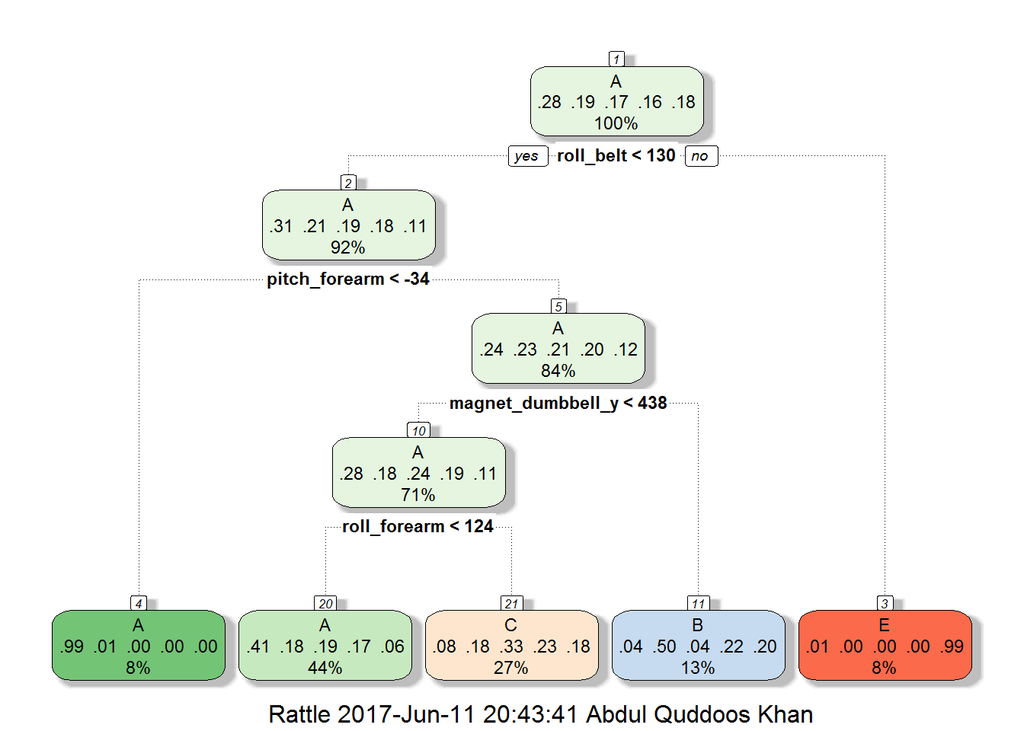

```r
fancyRpartPlot(fit_rpart$finalModel)
```

## Now create prediction using the validation set

```r
#get the predicton
predict_rpart <- predict(fit_rpart, valid)
(confusion_matpart <- confusionMatrix(valid$classe, predict_rpart))
```

```
## Confusion Matrix and Statistics
##
##           Reference
## Prediction    A    B    C    D    E
##          A 1544   21  107    0    2
##          B  492  391  256    0    0
##          C  474   38  514    0    0
##          D  436  175  353    0    0
##          E  155  138  293    0  496
##
## Overall Statistics
##
##                Accuracy : 0.5004
##                  95% CI : (0.4876, 0.5133)
##     No Information Rate : 0.5269
##     P-Value [Acc > NIR] : 1
##
##                   Kappa : 0.3464
##  Mcnemar's Test P-Value : NA
##
## Statistics by Class:
##
##                      Class: A Class: B Class: C Class: D Class: E
## Sensitivity            0.4979  0.51245  0.33749       NA  0.99598
## Specificity            0.9533  0.85396  0.88262   0.8362  0.89122
## Pos Pred Value         0.9223  0.34328  0.50097       NA  0.45841
## Neg Pred Value         0.6303  0.92162  0.79234       NA  0.99958
## Prevalence             0.5269  0.12965  0.25879   0.0000  0.08462
## Detection Rate         0.2624  0.06644  0.08734   0.0000  0.08428
## Detection Prevalence   0.2845  0.19354  0.17434   0.1638  0.18386
## Balanced Accuracy      0.7256  0.68321  0.61006       NA  0.94360
```

```r
(accuracy_rpart <- confusion_matpart$overall[1])
```

```
##  Accuracy
## 0.5004248
```

## Accuracy for Classification tree

Accuracy rate is .5 and out of sample error rate is 0.5 classification tree is not predicting classes well enough. ##Random forests

Prediction using random forest method

```r
fit_rf <- train(classe ~ ., data = train, method = "rf", trControl = control)

print(fit_rf, digits = 4)
```

```
## Random Forest
##
## 13737 samples
##    52 predictor
##     5 classes: 'A', 'B', 'C', 'D', 'E'
##
## No pre-processing
## Resampling: Cross-Validated (5 fold)
## Summary of sample sizes: 10990, 10990, 10990, 10988, 10990
## Resampling results across tuning parameters:
##
##   mtry  Accuracy  Kappa
##    2    0.9908    0.9884
##   27    0.9906    0.9881
##   52    0.9859    0.9821
##
## Accuracy was used to select the optimal model using  the largest value.
## The final value used for the model was mtry = 2.
```

```r
predict_rf <- predict(fit_rf, valid)
(conf_rf <- confusionMatrix(valid$classe, predict_rf));
```

```
## Confusion Matrix and Statistics
##
##           Reference
## Prediction    A    B    C    D    E
##          A 1673    0    0    0    1
##          B    1 1136    2    0    0
##          C    0    4 1020    2    0
##          D    0    0   21  941    2
##          E    0    0    0    2 1080
##
## Overall Statistics
##
##                Accuracy : 0.9941
##                  95% CI : (0.9917, 0.9959)
##     No Information Rate : 0.2845
##     P-Value [Acc > NIR] : < 2.2e-16
##
##                   Kappa : 0.9925
##  Mcnemar's Test P-Value : NA
##
## Statistics by Class:
##
##                      Class: A Class: B Class: C Class: D Class: E
## Sensitivity            0.9994   0.9965   0.9779   0.9958   0.9972
## Specificity            0.9998   0.9994   0.9988   0.9953   0.9996
## Pos Pred Value         0.9994   0.9974   0.9942   0.9761   0.9982
## Neg Pred Value         0.9998   0.9992   0.9953   0.9992   0.9994
## Prevalence             0.2845   0.1937   0.1772   0.1606   0.1840
## Detection Rate         0.2843   0.1930   0.1733   0.1599   0.1835
## Detection Prevalence   0.2845   0.1935   0.1743   0.1638   0.1839
## Balanced Accuracy      0.9996   0.9979   0.9884   0.9956   0.9984
```

Using the Validation set for RF predict result

```r
(accuracy_rf <- conf_rf$overall[1]);
```

```
##  Accuracy
## 0.9940527
```

```r
 (predict(fit_rf, test_data))
```

```
##  [1] B A B A A E D B A A B C B A E E A B B B
## Levels: A B C D E
```

We now use random forests to predict the outcome variable classe for the testing set.

[1] B A B A A E D B A A B C B A E E A B B B Levels: A B C D E